# Risk Factor Analysis

## Outcome Variable

**Outcome Variable:** ever_wasted

## Predictor Variables

**Intervention Variable:** enstunt

**Adjustment Set:**

unadjusted

## Stratifying Variables

The analysis was stratified on these variable(s):

- agecat
- studyid
- country

## Data Summary

| agecat | studyid | country | enstunt | ever_wasted | n_cell | n |
| --- | --- | --- | --- | --- | --- | --- |
| 0-24 months (no birth wast) | CMC-V-BCS-2002 | INDIA | 0 | 0 | 166 | 368 |
| 0-24 months (no birth wast) | CMC-V-BCS-2002 | INDIA | 0 | 1 | 127 | 368 |
| 0-24 months (no birth wast) | CMC-V-BCS-2002 | INDIA | 1 | 0 | 36 | 368 |
| 0-24 months (no birth wast) | CMC-V-BCS-2002 | INDIA | 1 | 1 | 39 | 368 |
| 0-24 months (no birth wast) | CMIN | BANGLADESH | 0 | 0 | 103 | 268 |
| 0-24 months (no birth wast) | CMIN | BANGLADESH | 0 | 1 | 63 | 268 |
| 0-24 months (no birth wast) | CMIN | BANGLADESH | 1 | 0 | 50 | 268 |
| 0-24 months (no birth wast) | CMIN | BANGLADESH | 1 | 1 | 52 | 268 |
| 0-24 months (no birth wast) | COHORTS | GUATEMALA | 0 | 0 | 910 | 1332 |
| 0-24 months (no birth wast) | COHORTS | GUATEMALA | 0 | 1 | 103 | 1332 |
| 0-24 months (no birth wast) | COHORTS | GUATEMALA | 1 | 0 | 263 | 1332 |
| 0-24 months (no birth wast) | COHORTS | GUATEMALA | 1 | 1 | 56 | 1332 |
| 0-24 months (no birth wast) | COHORTS | INDIA | 0 | 0 | 5189 | 7135 |
| 0-24 months (no birth wast) | COHORTS | INDIA | 0 | 1 | 1099 | 7135 |
| 0-24 months (no birth wast) | COHORTS | INDIA | 1 | 0 | 636 | 7135 |
| 0-24 months (no birth wast) | COHORTS | INDIA | 1 | 1 | 211 | 7135 |
| 0-24 months (no birth wast) | COHORTS | PHILIPPINES | 0 | 0 | 2004 | 3019 |
| 0-24 months (no birth wast) | COHORTS | PHILIPPINES | 0 | 1 | 841 | 3019 |
| 0-24 months (no birth wast) | COHORTS | PHILIPPINES | 1 | 0 | 99 | 3019 |
| 0-24 months (no birth wast) | COHORTS | PHILIPPINES | 1 | 1 | 75 | 3019 |
| 0-24 months (no birth wast) | CONTENT | PERU | 0 | 0 | 192 | 215 |
| 0-24 months (no birth wast) | CONTENT | PERU | 0 | 1 | 3 | 215 |
| 0-24 months (no birth wast) | CONTENT | PERU | 1 | 0 | 19 | 215 |
| 0-24 months (no birth wast) | CONTENT | PERU | 1 | 1 | 1 | 215 |
| 0-24 months (no birth wast) | EE | PAKISTAN | 0 | 0 | 111 | 377 |
| 0-24 months (no birth wast) | EE | PAKISTAN | 0 | 1 | 100 | 377 |
| 0-24 months (no birth wast) | EE | PAKISTAN | 1 | 0 | 63 | 377 |
| 0-24 months (no birth wast) | EE | PAKISTAN | 1 | 1 | 103 | 377 |
| 0-24 months (no birth wast) | GMS-Nepal | NEPAL | 0 | 0 | 275 | 660 |
| 0-24 months (no birth wast) | GMS-Nepal | NEPAL | 0 | 1 | 278 | 660 |

[output cut: 338 more lines]

The following strata were considered:

- agecat: 0-24 months (no birth wast), studyid: CMC-V-BCS-2002, country: INDIA
- agecat: 0-24 months (no birth wast), studyid: CMIN, country: BANGLADESH
- agecat: 0-24 months (no birth wast), studyid: COHORTS, country: GUATEMALA
- agecat: 0-24 months (no birth wast), studyid: COHORTS, country: INDIA
- agecat: 0-24 months (no birth wast), studyid: COHORTS, country: PHILIPPINES
- agecat: 0-24 months (no birth wast), studyid: CONTENT, country: PERU
- agecat: 0-24 months (no birth wast), studyid: EE, country: PAKISTAN
- agecat: 0-24 months (no birth wast), studyid: GMS-Nepal, country: NEPAL
- agecat: 0-24 months (no birth wast), studyid: Guatemala BSC, country: GUATEMALA
- agecat: 0-24 months (no birth wast), studyid: iLiNS-Zinc, country: BURKINA FASO
- agecat: 0-24 months (no birth wast), studyid: IRC, country: INDIA
- agecat: 0-24 months (no birth wast), studyid: JiVitA-3, country: BANGLADESH
- agecat: 0-24 months (no birth wast), studyid: JiVitA-4, country: BANGLADESH
- agecat: 0-24 months (no birth wast), studyid: Keneba, country: GAMBIA
- agecat: 0-24 months (no birth wast), studyid: LCNI-5, country: MALAWI
- agecat: 0-24 months (no birth wast), studyid: MAL-ED, country: BANGLADESH
- agecat: 0-24 months (no birth wast), studyid: MAL-ED, country: BRAZIL
- agecat: 0-24 months (no birth wast), studyid: MAL-ED, country: INDIA
- agecat: 0-24 months (no birth wast), studyid: MAL-ED, country: NEPAL
- agecat: 0-24 months (no birth wast), studyid: MAL-ED, country: PERU
- agecat: 0-24 months (no birth wast), studyid: MAL-ED, country: SOUTH AFRICA
- agecat: 0-24 months (no birth wast), studyid: MAL-ED, country: TANZANIA, UNITED REPUBLIC OF
- agecat: 0-24 months (no birth wast), studyid: NIH-Birth, country: BANGLADESH
- agecat: 0-24 months (no birth wast), studyid: NIH-Crypto, country: BANGLADESH
- agecat: 0-24 months (no birth wast), studyid: PROBIT, country: BELARUS
- agecat: 0-24 months (no birth wast), studyid: PROVIDE, country: BANGLADESH
- agecat: 0-24 months (no birth wast), studyid: ResPak, country: PAKISTAN
- agecat: 0-24 months (no birth wast), studyid: SAS-CompFeed, country: INDIA
- agecat: 0-24 months (no birth wast), studyid: SAS-FoodSuppl, country: INDIA
- agecat: 0-24 months (no birth wast), studyid: TanzaniaChild2, country: TANZANIA, UNITED REPUBLIC OF
- agecat: 0-24 months (no birth wast), studyid: ZVITAMBO, country: ZIMBABWE
- agecat: 0-6 months (no birth wast), studyid: CMC-V-BCS-2002, country: INDIA
- agecat: 0-6 months (no birth wast), studyid: CMIN, country: BANGLADESH
- agecat: 0-6 months (no birth wast), studyid: COHORTS, country: GUATEMALA
- agecat: 0-6 months (no birth wast), studyid: COHORTS, country: INDIA
- agecat: 0-6 months (no birth wast), studyid: COHORTS, country: PHILIPPINES
- agecat: 0-6 months (no birth wast), studyid: CONTENT, country: PERU
- agecat: 0-6 months (no birth wast), studyid: EE, country: PAKISTAN
- agecat: 0-6 months (no birth wast), studyid: GMS-Nepal, country: NEPAL
- agecat: 0-6 months (no birth wast), studyid: Guatemala BSC, country: GUATEMALA
- agecat: 0-6 months (no birth wast), studyid: IRC, country: INDIA
- agecat: 0-6 months (no birth wast), studyid: JiVitA-3, country: BANGLADESH
- agecat: 0-6 months (no birth wast), studyid: JiVitA-4, country: BANGLADESH
- agecat: 0-6 months (no birth wast), studyid: Keneba, country: GAMBIA
- agecat: 0-6 months (no birth wast), studyid: LCNI-5, country: MALAWI
- agecat: 0-6 months (no birth wast), studyid: MAL-ED, country: BANGLADESH
- agecat: 0-6 months (no birth wast), studyid: MAL-ED, country: BRAZIL
- agecat: 0-6 months (no birth wast), studyid: MAL-ED, country: INDIA
- agecat: 0-6 months (no birth wast), studyid: MAL-ED, country: NEPAL
- agecat: 0-6 months (no birth wast), studyid: MAL-ED, country: PERU
- agecat: 0-6 months (no birth wast), studyid: MAL-ED, country: SOUTH AFRICA
- agecat: 0-6 months (no birth wast), studyid: MAL-ED, country: TANZANIA, UNITED REPUBLIC OF
- agecat: 0-6 months (no birth wast), studyid: NIH-Birth, country: BANGLADESH
- agecat: 0-6 months (no birth wast), studyid: NIH-Crypto, country: BANGLADESH
- agecat: 0-6 months (no birth wast), studyid: PROBIT, country: BELARUS
- agecat: 0-6 months (no birth wast), studyid: PROVIDE, country: BANGLADESH
- agecat: 0-6 months (no birth wast), studyid: ResPak, country: PAKISTAN
- agecat: 0-6 months (no birth wast), studyid: SAS-CompFeed, country: INDIA
- agecat: 0-6 months (no birth wast), studyid: SAS-FoodSuppl, country: INDIA
- agecat: 0-6 months (no birth wast), studyid: TanzaniaChild2, country: TANZANIA, UNITED REPUBLIC OF
- agecat: 0-6 months (no birth wast), studyid: ZVITAMBO, country: ZIMBABWE
- agecat: 6-24 months, studyid: CMC-V-BCS-2002, country: INDIA
- agecat: 6-24 months, studyid: CMIN, country: BANGLADESH
- agecat: 6-24 months, studyid: COHORTS, country: GUATEMALA
- agecat: 6-24 months, studyid: COHORTS, country: INDIA
- agecat: 6-24 months, studyid: COHORTS, country: PHILIPPINES
- agecat: 6-24 months, studyid: CONTENT, country: PERU
- agecat: 6-24 months, studyid: EE, country: PAKISTAN
- agecat: 6-24 months, studyid: GMS-Nepal, country: NEPAL
- agecat: 6-24 months, studyid: Guatemala BSC, country: GUATEMALA
- agecat: 6-24 months, studyid: iLiNS-Zinc, country: BURKINA FASO
- agecat: 6-24 months, studyid: IRC, country: INDIA
- agecat: 6-24 months, studyid: JiVitA-3, country: BANGLADESH
- agecat: 6-24 months, studyid: JiVitA-4, country: BANGLADESH
- agecat: 6-24 months, studyid: Keneba, country: GAMBIA
- agecat: 6-24 months, studyid: LCNI-5, country: MALAWI
- agecat: 6-24 months, studyid: MAL-ED, country: BANGLADESH
- agecat: 6-24 months, studyid: MAL-ED, country: BRAZIL
- agecat: 6-24 months, studyid: MAL-ED, country: INDIA
- agecat: 6-24 months, studyid: MAL-ED, country: NEPAL
- agecat: 6-24 months, studyid: MAL-ED, country: PERU
- agecat: 6-24 months, studyid: MAL-ED, country: SOUTH AFRICA
- agecat: 6-24 months, studyid: MAL-ED, country: TANZANIA, UNITED REPUBLIC OF
- agecat: 6-24 months, studyid: NIH-Birth, country: BANGLADESH
- agecat: 6-24 months, studyid: NIH-Crypto, country: BANGLADESH
- agecat: 6-24 months, studyid: PROBIT, country: BELARUS
- agecat: 6-24 months, studyid: PROVIDE, country: BANGLADESH
- agecat: 6-24 months, studyid: ResPak, country: PAKISTAN
- agecat: 6-24 months, studyid: SAS-CompFeed, country: INDIA
- agecat: 6-24 months, studyid: SAS-FoodSuppl, country: INDIA
- agecat: 6-24 months, studyid: TanzaniaChild2, country: TANZANIA, UNITED REPUBLIC OF
- agecat: 6-24 months, studyid: ZVITAMBO, country: ZIMBABWE

### Dropped Strata

Some strata were dropped due to rare outcomes:

- agecat: 0-24 months (no birth wast), studyid: CONTENT, country: PERU
- agecat: 0-24 months (no birth wast), studyid: MAL-ED, country: BRAZIL
- agecat: 0-6 months (no birth wast), studyid: COHORTS, country: GUATEMALA
- agecat: 0-6 months (no birth wast), studyid: CONTENT, country: PERU
- agecat: 0-6 months (no birth wast), studyid: Guatemala BSC, country: GUATEMALA
- agecat: 0-6 months (no birth wast), studyid: LCNI-5, country: MALAWI
- agecat: 0-6 months (no birth wast), studyid: MAL-ED, country: BRAZIL
- agecat: 0-6 months (no birth wast), studyid: MAL-ED, country: NEPAL
- agecat: 0-6 months (no birth wast), studyid: MAL-ED, country: PERU
- agecat: 0-6 months (no birth wast), studyid: MAL-ED, country: SOUTH AFRICA
- agecat: 0-6 months (no birth wast), studyid: MAL-ED, country: TANZANIA, UNITED REPUBLIC OF
- agecat: 0-6 months (no birth wast), studyid: NIH-Crypto, country: BANGLADESH
- agecat: 0-6 months (no birth wast), studyid: SAS-FoodSuppl, country: INDIA
- agecat: 6-24 months, studyid: CONTENT, country: PERU
- agecat: 6-24 months, studyid: MAL-ED, country: BRAZIL
- agecat: 6-24 months, studyid: PROBIT, country: BELARUS

## Methods Detail

We’re interested in the causal parameters $E[Y_a]$ for all values of $a \in \mathcal{A}$. These parameters represent the mean outcome if, possibly contrary to fact, we intervened to set all units to have $A=a$. Under the randomization and positivity assumptions, these are identified by the statistical parameters $\psi_a=E_W[E_{Y|A,W}(Y|A=a,W)]$. In addition, we’re interested in the mean of $Y$, $E[Y]$ under no intervention (the observed mean). We will estimate these parameters by using SuperLearner to fit the relevant likelihood factors – $E_{Y|A,W}(Y|A=a,W)$ and $p(A=a|W)$, and then updating our likelihood fit using a joint TMLE.

For unadjusted analyses ($W=\{\}$), initial likelihoods were estimated using Lrnr_glm to estimate the simple $E(Y|A)$ and Lrnr_mean to estimate $p(A)$. For adjusted analyses, a small library containing Lrnr_glmnet, Lrnr_xgboost, and Lrnr_mean was used.

Having estimated these parameters, we will then use the delta method to estimate relative risks and attributable risks relative to a prespecified baseline level of $A$.

# Results Detail

## Results Plots

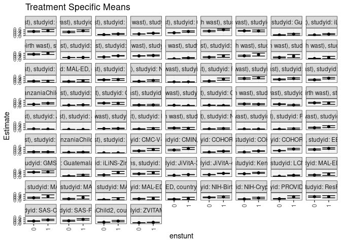

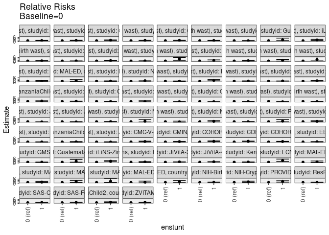

[figure not shown]

[figure not shown]

## Results Table

### Parameter: TSM

| agecat | studyid | country | intervention_level | baseline_level | estimate | ci_lower | ci_upper |
| --- | --- | --- | --- | --- | --- | --- | --- |
| 0-24 months (no birth wast) | CMC-V-BCS-2002 | INDIA | 0 | NA | 0.4334471 | 0.3766281 | 0.4902661 |
| 0-24 months (no birth wast) | CMC-V-BCS-2002 | INDIA | 1 | NA | 0.5200000 | 0.4067781 | 0.6332219 |
| 0-24 months (no birth wast) | CMIN | BANGLADESH | 0 | NA | 0.3795181 | 0.3055598 | 0.4534763 |
| 0-24 months (no birth wast) | CMIN | BANGLADESH | 1 | NA | 0.5098039 | 0.4126084 | 0.6069994 |
| 0-24 months (no birth wast) | COHORTS | GUATEMALA | 0 | NA | 0.1016782 | 0.0830600 | 0.1202963 |
| 0-24 months (no birth wast) | COHORTS | GUATEMALA | 1 | NA | 0.1755486 | 0.1337851 | 0.2173121 |
| 0-24 months (no birth wast) | COHORTS | INDIA | 0 | NA | 0.1747774 | 0.1653898 | 0.1841649 |
| 0-24 months (no birth wast) | COHORTS | INDIA | 1 | NA | 0.2491145 | 0.2199857 | 0.2782434 |
| 0-24 months (no birth wast) | COHORTS | PHILIPPINES | 0 | NA | 0.2956063 | 0.2788359 | 0.3123767 |
| 0-24 months (no birth wast) | COHORTS | PHILIPPINES | 1 | NA | 0.4310345 | 0.3574401 | 0.5046288 |
| 0-24 months (no birth wast) | EE | PAKISTAN | 0 | NA | 0.4739336 | 0.4064711 | 0.5413962 |
| 0-24 months (no birth wast) | EE | PAKISTAN | 1 | NA | 0.6204819 | 0.5465637 | 0.6944002 |
| 0-24 months (no birth wast) | GMS-Nepal | NEPAL | 0 | NA | 0.5027125 | 0.4610084 | 0.5444165 |
| 0-24 months (no birth wast) | GMS-Nepal | NEPAL | 1 | NA | 0.4953271 | 0.4005210 | 0.5901333 |
| 0-24 months (no birth wast) | Guatemala BSC | GUATEMALA | 0 | NA | 0.0627615 | 0.0319640 | 0.0935590 |
| 0-24 months (no birth wast) | Guatemala BSC | GUATEMALA | 1 | NA | 0.1486486 | 0.0674662 | 0.2298311 |
| 0-24 months (no birth wast) | iLiNS-Zinc | BURKINA FASO | 0 | NA | 0.0682747 | 0.0535502 | 0.0829992 |
| 0-24 months (no birth wast) | iLiNS-Zinc | BURKINA FASO | 1 | NA | 0.1488372 | 0.0941917 | 0.2034827 |
| 0-24 months (no birth wast) | IRC | INDIA | 0 | NA | 0.5070028 | 0.4550782 | 0.5589274 |
| 0-24 months (no birth wast) | IRC | INDIA | 1 | NA | 0.6153846 | 0.4829917 | 0.7477775 |
| 0-24 months (no birth wast) | JiVitA-3 | BANGLADESH | 0 | NA | 0.1648327 | 0.1585706 | 0.1710949 |
| 0-24 months (no birth wast) | JiVitA-3 | BANGLADESH | 1 | NA | 0.1791805 | 0.1699715 | 0.1883895 |
| 0-24 months (no birth wast) | JiVitA-4 | BANGLADESH | 0 | NA | 0.2225965 | 0.2073085 | 0.2378845 |
| 0-24 months (no birth wast) | JiVitA-4 | BANGLADESH | 1 | NA | 0.3461288 | 0.3193440 | 0.3729137 |
| 0-24 months (no birth wast) | Keneba | GAMBIA | 0 | NA | 0.3345098 | 0.3161939 | 0.3528257 |
| 0-24 months (no birth wast) | Keneba | GAMBIA | 1 | NA | 0.3773585 | 0.3240733 | 0.4306437 |
| 0-24 months (no birth wast) | LCNI-5 | MALAWI | 0 | NA | 0.0339623 | 0.0185323 | 0.0493922 |
| 0-24 months (no birth wast) | LCNI-5 | MALAWI | 1 | NA | 0.1237785 | 0.0869174 | 0.1606396 |
| 0-24 months (no birth wast) | MAL-ED | BANGLADESH | 0 | NA | 0.1981567 | 0.1450200 | 0.2512934 |
| 0-24 months (no birth wast) | MAL-ED | BANGLADESH | 1 | NA | 0.3260870 | 0.1903603 | 0.4618136 |

[output cut: 122 more lines]

### Parameter: E(Y)

| agecat | studyid | country | intervention_level | baseline_level | estimate | ci_lower | ci_upper |
| --- | --- | --- | --- | --- | --- | --- | --- |
| 0-24 months (no birth wast) | CMC-V-BCS-2002 | INDIA | NA | NA | 0.4510870 | 0.4001777 | 0.5019962 |
| 0-24 months (no birth wast) | CMIN | BANGLADESH | NA | NA | 0.4291045 | 0.3697365 | 0.4884725 |
| 0-24 months (no birth wast) | COHORTS | GUATEMALA | NA | NA | 0.1193694 | 0.1019512 | 0.1367875 |
| 0-24 months (no birth wast) | COHORTS | INDIA | NA | NA | 0.1836020 | 0.1746179 | 0.1925860 |
| 0-24 months (no birth wast) | COHORTS | PHILIPPINES | NA | NA | 0.3034117 | 0.2870099 | 0.3198136 |
| 0-24 months (no birth wast) | EE | PAKISTAN | NA | NA | 0.5384615 | 0.4880726 | 0.5888505 |
| 0-24 months (no birth wast) | GMS-Nepal | NEPAL | NA | NA | 0.5015152 | 0.4633406 | 0.5396897 |
| 0-24 months (no birth wast) | Guatemala BSC | GUATEMALA | NA | NA | 0.0830671 | 0.0524436 | 0.1136905 |
| 0-24 months (no birth wast) | iLiNS-Zinc | BURKINA FASO | NA | NA | 0.0850857 | 0.0676201 | 0.1025513 |
| 0-24 months (no birth wast) | IRC | INDIA | NA | NA | 0.5207824 | 0.4723080 | 0.5692568 |
| 0-24 months (no birth wast) | JiVitA-3 | BANGLADESH | NA | NA | 0.1693995 | 0.1641138 | 0.1746853 |
| 0-24 months (no birth wast) | JiVitA-4 | BANGLADESH | NA | NA | 0.2577835 | 0.2441424 | 0.2714247 |
| 0-24 months (no birth wast) | Keneba | GAMBIA | NA | NA | 0.3392608 | 0.3219301 | 0.3565915 |
| 0-24 months (no birth wast) | LCNI-5 | MALAWI | NA | NA | 0.0669056 | 0.0499685 | 0.0838427 |
| 0-24 months (no birth wast) | MAL-ED | BANGLADESH | NA | NA | 0.2205323 | 0.1703290 | 0.2707357 |
| 0-24 months (no birth wast) | MAL-ED | INDIA | NA | NA | 0.3699187 | 0.3094659 | 0.4303715 |
| 0-24 months (no birth wast) | MAL-ED | NEPAL | NA | NA | 0.1924686 | 0.1423823 | 0.2425550 |
| 0-24 months (no birth wast) | MAL-ED | PERU | NA | NA | 0.0695364 | 0.0408008 | 0.0982721 |
| 0-24 months (no birth wast) | MAL-ED | SOUTH AFRICA | NA | NA | 0.1461039 | 0.1065934 | 0.1856144 |
| 0-24 months (no birth wast) | MAL-ED | TANZANIA, UNITED REPUBLIC OF | NA | NA | 0.1302682 | 0.0893541 | 0.1711823 |
| 0-24 months (no birth wast) | NIH-Birth | BANGLADESH | NA | NA | 0.2956811 | 0.2591967 | 0.3321655 |
| 0-24 months (no birth wast) | NIH-Crypto | BANGLADESH | NA | NA | 0.1432361 | 0.1182149 | 0.1682572 |
| 0-24 months (no birth wast) | PROBIT | BELARUS | NA | NA | 0.0680135 | 0.0562135 | 0.0798135 |
| 0-24 months (no birth wast) | PROVIDE | BANGLADESH | NA | NA | 0.1775837 | 0.1489858 | 0.2061816 |
| 0-24 months (no birth wast) | ResPak | PAKISTAN | NA | NA | 0.4535714 | 0.3951549 | 0.5119879 |
| 0-24 months (no birth wast) | SAS-CompFeed | INDIA | NA | NA | 0.3615180 | 0.3107193 | 0.4123167 |
| 0-24 months (no birth wast) | SAS-FoodSuppl | INDIA | NA | NA | 0.3602015 | 0.3129196 | 0.4074834 |
| 0-24 months (no birth wast) | TanzaniaChild2 | TANZANIA, UNITED REPUBLIC OF | NA | NA | 0.1988255 | 0.1828010 | 0.2148500 |
| 0-24 months (no birth wast) | ZVITAMBO | ZIMBABWE | NA | NA | 0.1020019 | 0.0969221 | 0.1070817 |
| 0-6 months (no birth wast) | CMC-V-BCS-2002 | INDIA | NA | NA | 0.3085714 | 0.2601110 | 0.3570318 |
| 0-6 months (no birth wast) | CMIN | BANGLADESH | NA | NA | 0.1161049 | 0.0776073 | 0.1546024 |
| 0-6 months (no birth wast) | COHORTS | INDIA | NA | NA | 0.0820276 | 0.0753613 | 0.0886940 |
| 0-6 months (no birth wast) | COHORTS | PHILIPPINES | NA | NA | 0.0947298 | 0.0842456 | 0.1052141 |
| 0-6 months (no birth wast) | EE | PAKISTAN | NA | NA | 0.2160000 | 0.1742941 | 0.2577059 |
| 0-6 months (no birth wast) | GMS-Nepal | NEPAL | NA | NA | 0.1915888 | 0.1611224 | 0.2220551 |
| 0-6 months (no birth wast) | IRC | INDIA | NA | NA | 0.3410256 | 0.2939169 | 0.3881343 |
| 0-6 months (no birth wast) | JiVitA-3 | BANGLADESH | NA | NA | 0.0717008 | 0.0680635 | 0.0753382 |
| 0-6 months (no birth wast) | JiVitA-4 | BANGLADESH | NA | NA | 0.0256203 | 0.0209093 | 0.0303314 |
| 0-6 months (no birth wast) | Keneba | GAMBIA | NA | NA | 0.1117987 | 0.0992515 | 0.1243458 |
| 0-6 months (no birth wast) | MAL-ED | BANGLADESH | NA | NA | 0.0725191 | 0.0410556 | 0.1039825 |
| 0-6 months (no birth wast) | MAL-ED | INDIA | NA | NA | 0.1598361 | 0.1137612 | 0.2059110 |
| 0-6 months (no birth wast) | NIH-Birth | BANGLADESH | NA | NA | 0.0787671 | 0.0569010 | 0.1006332 |
| 0-6 months (no birth wast) | PROBIT | BELARUS | NA | NA | 0.0612233 | 0.0502388 | 0.0722078 |
| 0-6 months (no birth wast) | PROVIDE | BANGLADESH | NA | NA | 0.0541728 | 0.0371844 | 0.0711612 |
| 0-6 months (no birth wast) | ResPak | PAKISTAN | NA | NA | 0.2282609 | 0.1786550 | 0.2778667 |
| 0-6 months (no birth wast) | SAS-CompFeed | INDIA | NA | NA | 0.1255940 | 0.0954030 | 0.1557851 |
| 0-6 months (no birth wast) | TanzaniaChild2 | TANZANIA, UNITED REPUBLIC OF | NA | NA | 0.0858586 | 0.0745914 | 0.0971258 |
| 0-6 months (no birth wast) | ZVITAMBO | ZIMBABWE | NA | NA | 0.0319976 | 0.0290150 | 0.0349802 |
| 6-24 months | CMC-V-BCS-2002 | INDIA | NA | NA | 0.2654155 | 0.2205451 | 0.3102860 |
| 6-24 months | CMIN | BANGLADESH | NA | NA | 0.3849206 | 0.3247254 | 0.4451159 |
| 6-24 months | COHORTS | GUATEMALA | NA | NA | 0.1262295 | 0.1075861 | 0.1448729 |
| 6-24 months | COHORTS | INDIA | NA | NA | 0.1226048 | 0.1148883 | 0.1303213 |
| 6-24 months | COHORTS | PHILIPPINES | NA | NA | 0.2666429 | 0.2502871 | 0.2829988 |
| 6-24 months | EE | PAKISTAN | NA | NA | 0.4304813 | 0.3802326 | 0.4807300 |
| 6-24 months | GMS-Nepal | NEPAL | NA | NA | 0.4728814 | 0.4325613 | 0.5132014 |
| 6-24 months | Guatemala BSC | GUATEMALA | NA | NA | 0.0830325 | 0.0504792 | 0.1155858 |
| 6-24 months | iLiNS-Zinc | BURKINA FASO | NA | NA | 0.2317820 | 0.2038933 | 0.2596707 |
| 6-24 months | IRC | INDIA | NA | NA | 0.3097561 | 0.2649438 | 0.3545684 |
| 6-24 months | JiVitA-3 | BANGLADESH | NA | NA | 0.1640074 | 0.1578946 | 0.1701202 |
| 6-24 months | JiVitA-4 | BANGLADESH | NA | NA | 0.2473297 | 0.2337864 | 0.2608729 |
| 6-24 months | Keneba | GAMBIA | NA | NA | 0.3166545 | 0.2992274 | 0.3340815 |
| 6-24 months | LCNI-5 | MALAWI | NA | NA | 0.0774818 | 0.0592383 | 0.0957254 |
| 6-24 months | MAL-ED | BANGLADESH | NA | NA | 0.1791667 | 0.1305478 | 0.2277856 |
| 6-24 months | MAL-ED | INDIA | NA | NA | 0.2723404 | 0.2153029 | 0.3293779 |
| 6-24 months | MAL-ED | NEPAL | NA | NA | 0.1531915 | 0.1070438 | 0.1993392 |
| 6-24 months | MAL-ED | PERU | NA | NA | 0.0666667 | 0.0368579 | 0.0964755 |
| 6-24 months | MAL-ED | SOUTH AFRICA | NA | NA | 0.1428571 | 0.1001583 | 0.1855560 |
| 6-24 months | MAL-ED | TANZANIA, UNITED REPUBLIC OF | NA | NA | 0.1142857 | 0.0743652 | 0.1542062 |
| 6-24 months | NIH-Birth | BANGLADESH | NA | NA | 0.2933579 | 0.2549918 | 0.3317241 |
| 6-24 months | NIH-Crypto | BANGLADESH | NA | NA | 0.1315068 | 0.1069744 | 0.1560393 |
| 6-24 months | PROVIDE | BANGLADESH | NA | NA | 0.1609756 | 0.1319065 | 0.1900447 |
| 6-24 months | ResPak | PAKISTAN | NA | NA | 0.3644068 | 0.3028753 | 0.4259382 |
| 6-24 months | SAS-CompFeed | INDIA | NA | NA | 0.3059755 | 0.2638053 | 0.3481458 |
| 6-24 months | SAS-FoodSuppl | INDIA | NA | NA | 0.3557214 | 0.3088651 | 0.4025777 |
| 6-24 months | TanzaniaChild2 | TANZANIA, UNITED REPUBLIC OF | NA | NA | 0.1605550 | 0.1445335 | 0.1765765 |
| 6-24 months | ZVITAMBO | ZIMBABWE | NA | NA | 0.0958853 | 0.0903360 | 0.1014347 |

### Parameter: RR

| agecat | studyid | country | intervention_level | baseline_level | estimate | ci_lower | ci_upper |
| --- | --- | --- | --- | --- | --- | --- | --- |
| 0-24 months (no birth wast) | CMC-V-BCS-2002 | INDIA | 0 | 0 | 1.0000000 | 1.0000000 | 1.0000000 |
| 0-24 months (no birth wast) | CMC-V-BCS-2002 | INDIA | 1 | 0 | 1.1996850 | 0.9304468 | 1.5468313 |
| 0-24 months (no birth wast) | CMIN | BANGLADESH | 0 | 0 | 1.0000000 | 1.0000000 | 1.0000000 |
| 0-24 months (no birth wast) | CMIN | BANGLADESH | 1 | 0 | 1.3432929 | 1.0227540 | 1.7642911 |
| 0-24 months (no birth wast) | COHORTS | GUATEMALA | 0 | 0 | 1.0000000 | 1.0000000 | 1.0000000 |
| 0-24 months (no birth wast) | COHORTS | GUATEMALA | 1 | 0 | 1.7265119 | 1.2787619 | 2.3310385 |
| 0-24 months (no birth wast) | COHORTS | INDIA | 0 | 0 | 1.0000000 | 1.0000000 | 1.0000000 |
| 0-24 months (no birth wast) | COHORTS | INDIA | 1 | 0 | 1.4253249 | 1.2532300 | 1.6210522 |
| 0-24 months (no birth wast) | COHORTS | PHILIPPINES | 0 | 0 | 1.0000000 | 1.0000000 | 1.0000000 |
| 0-24 months (no birth wast) | COHORTS | PHILIPPINES | 1 | 0 | 1.4581369 | 1.2180388 | 1.7455627 |
| 0-24 months (no birth wast) | EE | PAKISTAN | 0 | 0 | 1.0000000 | 1.0000000 | 1.0000000 |
| 0-24 months (no birth wast) | EE | PAKISTAN | 1 | 0 | 1.3092169 | 1.0874224 | 1.5762493 |
| 0-24 months (no birth wast) | GMS-Nepal | NEPAL | 0 | 0 | 1.0000000 | 1.0000000 | 1.0000000 |
| 0-24 months (no birth wast) | GMS-Nepal | NEPAL | 1 | 0 | 0.9853089 | 0.7997901 | 1.2138606 |
| 0-24 months (no birth wast) | Guatemala BSC | GUATEMALA | 0 | 0 | 1.0000000 | 1.0000000 | 1.0000000 |
| 0-24 months (no birth wast) | Guatemala BSC | GUATEMALA | 1 | 0 | 2.3684685 | 1.1365957 | 4.9354777 |
| 0-24 months (no birth wast) | iLiNS-Zinc | BURKINA FASO | 0 | 0 | 1.0000000 | 1.0000000 | 1.0000000 |
| 0-24 months (no birth wast) | iLiNS-Zinc | BURKINA FASO | 1 | 0 | 2.1799749 | 1.4888153 | 3.1919948 |
| 0-24 months (no birth wast) | IRC | INDIA | 0 | 0 | 1.0000000 | 1.0000000 | 1.0000000 |
| 0-24 months (no birth wast) | IRC | INDIA | 1 | 0 | 1.2137697 | 0.9564368 | 1.5403389 |
| 0-24 months (no birth wast) | JiVitA-3 | BANGLADESH | 0 | 0 | 1.0000000 | 1.0000000 | 1.0000000 |
| 0-24 months (no birth wast) | JiVitA-3 | BANGLADESH | 1 | 0 | 1.0870443 | 1.0211416 | 1.1572002 |
| 0-24 months (no birth wast) | JiVitA-4 | BANGLADESH | 0 | 0 | 1.0000000 | 1.0000000 | 1.0000000 |
| 0-24 months (no birth wast) | JiVitA-4 | BANGLADESH | 1 | 0 | 1.5549606 | 1.4057521 | 1.7200062 |
| 0-24 months (no birth wast) | Keneba | GAMBIA | 0 | 0 | 1.0000000 | 1.0000000 | 1.0000000 |
| 0-24 months (no birth wast) | Keneba | GAMBIA | 1 | 0 | 1.1280940 | 0.9695526 | 1.3125601 |
| 0-24 months (no birth wast) | LCNI-5 | MALAWI | 0 | 0 | 1.0000000 | 1.0000000 | 1.0000000 |
| 0-24 months (no birth wast) | LCNI-5 | MALAWI | 1 | 0 | 3.6445892 | 2.1170324 | 6.2743633 |
| 0-24 months (no birth wast) | MAL-ED | BANGLADESH | 0 | 0 | 1.0000000 | 1.0000000 | 1.0000000 |
| 0-24 months (no birth wast) | MAL-ED | BANGLADESH | 1 | 0 | 1.6456016 | 1.0029811 | 2.6999558 |

[output cut: 122 more lines]

### Parameter: PAR

| agecat | studyid | country | intervention_level | baseline_level | estimate | ci_lower | ci_upper |
| --- | --- | --- | --- | --- | --- | --- | --- |
| 0-24 months (no birth wast) | CMC-V-BCS-2002 | INDIA | 0 | NA | 0.0176399 | -0.0084232 | 0.0437029 |
| 0-24 months (no birth wast) | CMIN | BANGLADESH | 0 | NA | 0.0495864 | 0.0024872 | 0.0966856 |
| 0-24 months (no birth wast) | COHORTS | GUATEMALA | 0 | NA | 0.0176912 | 0.0066102 | 0.0287722 |
| 0-24 months (no birth wast) | COHORTS | INDIA | 0 | NA | 0.0088246 | 0.0051490 | 0.0125002 |
| 0-24 months (no birth wast) | COHORTS | PHILIPPINES | 0 | NA | 0.0078054 | 0.0033117 | 0.0122991 |
| 0-24 months (no birth wast) | EE | PAKISTAN | 0 | NA | 0.0645279 | 0.0198535 | 0.1092023 |
| 0-24 months (no birth wast) | GMS-Nepal | NEPAL | 0 | NA | -0.0011973 | -0.0179900 | 0.0155954 |
| 0-24 months (no birth wast) | Guatemala BSC | GUATEMALA | 0 | NA | 0.0203056 | -0.0006179 | 0.0412291 |
| 0-24 months (no birth wast) | iLiNS-Zinc | BURKINA FASO | 0 | NA | 0.0168110 | 0.0082533 | 0.0253687 |
| 0-24 months (no birth wast) | IRC | INDIA | 0 | NA | 0.0137796 | -0.0046373 | 0.0321965 |
| 0-24 months (no birth wast) | JiVitA-3 | BANGLADESH | 0 | NA | 0.0045668 | 0.0010901 | 0.0080435 |
| 0-24 months (no birth wast) | JiVitA-4 | BANGLADESH | 0 | NA | 0.0351870 | 0.0264870 | 0.0438870 |
| 0-24 months (no birth wast) | Keneba | GAMBIA | 0 | NA | 0.0047510 | -0.0015159 | 0.0110179 |
| 0-24 months (no birth wast) | LCNI-5 | MALAWI | 0 | NA | 0.0329434 | 0.0179957 | 0.0478910 |
| 0-24 months (no birth wast) | MAL-ED | BANGLADESH | 0 | NA | 0.0223756 | -0.0037884 | 0.0485397 |
| 0-24 months (no birth wast) | MAL-ED | INDIA | 0 | NA | 0.0204041 | -0.0075593 | 0.0483675 |
| 0-24 months (no birth wast) | MAL-ED | NEPAL | 0 | NA | 0.0162781 | -0.0058443 | 0.0384006 |
| 0-24 months (no birth wast) | MAL-ED | PERU | 0 | NA | 0.0131454 | -0.0022995 | 0.0285904 |
| 0-24 months (no birth wast) | MAL-ED | SOUTH AFRICA | 0 | NA | -0.0020443 | -0.0163339 | 0.0122454 |
| 0-24 months (no birth wast) | MAL-ED | TANZANIA, UNITED REPUBLIC OF | 0 | NA | 0.0115467 | -0.0090588 | 0.0321522 |
| 0-24 months (no birth wast) | NIH-Birth | BANGLADESH | 0 | NA | 0.0043425 | -0.0116466 | 0.0203315 |
| 0-24 months (no birth wast) | NIH-Crypto | BANGLADESH | 0 | NA | 0.0122654 | 0.0004605 | 0.0240702 |
| 0-24 months (no birth wast) | PROBIT | BELARUS | 0 | NA | 0.0000013 | -0.0005524 | 0.0005550 |
| 0-24 months (no birth wast) | PROVIDE | BANGLADESH | 0 | NA | 0.0197737 | 0.0074169 | 0.0321305 |
| 0-24 months (no birth wast) | ResPak | PAKISTAN | 0 | NA | 0.0214106 | -0.0161257 | 0.0589470 |
| 0-24 months (no birth wast) | SAS-CompFeed | INDIA | 0 | NA | 0.0263379 | 0.0132715 | 0.0394044 |
| 0-24 months (no birth wast) | SAS-FoodSuppl | INDIA | 0 | NA | 0.0610212 | 0.0225892 | 0.0994531 |
| 0-24 months (no birth wast) | TanzaniaChild2 | TANZANIA, UNITED REPUBLIC OF | 0 | NA | 0.0071063 | 0.0020869 | 0.0121257 |
| 0-24 months (no birth wast) | ZVITAMBO | ZIMBABWE | 0 | NA | 0.0031699 | 0.0012803 | 0.0050595 |
| 0-6 months (no birth wast) | CMC-V-BCS-2002 | INDIA | 0 | NA | -0.0057143 | -0.0295745 | 0.0181460 |
| 0-6 months (no birth wast) | CMIN | BANGLADESH | 0 | NA | 0.0016470 | -0.0285010 | 0.0317950 |
| 0-6 months (no birth wast) | COHORTS | INDIA | 0 | NA | -0.0033509 | -0.0053807 | -0.0013210 |
| 0-6 months (no birth wast) | COHORTS | PHILIPPINES | 0 | NA | -0.0018732 | -0.0040792 | 0.0003329 |
| 0-6 months (no birth wast) | EE | PAKISTAN | 0 | NA | -0.0125714 | -0.0493313 | 0.0241884 |
| 0-6 months (no birth wast) | GMS-Nepal | NEPAL | 0 | NA | -0.0151151 | -0.0268473 | -0.0033830 |
| 0-6 months (no birth wast) | IRC | INDIA | 0 | NA | -0.0041071 | -0.0220808 | 0.0138666 |
| 0-6 months (no birth wast) | JiVitA-3 | BANGLADESH | 0 | NA | -0.0081762 | -0.0104311 | -0.0059213 |
| 0-6 months (no birth wast) | JiVitA-4 | BANGLADESH | 0 | NA | -0.0027027 | -0.0054044 | -0.0000010 |
| 0-6 months (no birth wast) | Keneba | GAMBIA | 0 | NA | 0.0008398 | -0.0033728 | 0.0050523 |
| 0-6 months (no birth wast) | MAL-ED | BANGLADESH | 0 | NA | 0.0077043 | -0.0092607 | 0.0246693 |
| 0-6 months (no birth wast) | MAL-ED | INDIA | 0 | NA | -0.0060176 | -0.0247773 | 0.0127421 |
| 0-6 months (no birth wast) | NIH-Birth | BANGLADESH | 0 | NA | 0.0060399 | -0.0046214 | 0.0167011 |
| 0-6 months (no birth wast) | PROBIT | BELARUS | 0 | NA | 0.0000025 | -0.0004502 | 0.0004551 |
| 0-6 months (no birth wast) | PROVIDE | BANGLADESH | 0 | NA | 0.0040110 | -0.0029505 | 0.0109724 |
| 0-6 months (no birth wast) | ResPak | PAKISTAN | 0 | NA | 0.0312912 | -0.0021998 | 0.0647821 |
| 0-6 months (no birth wast) | SAS-CompFeed | INDIA | 0 | NA | -0.0013901 | -0.0075732 | 0.0047930 |
| 0-6 months (no birth wast) | TanzaniaChild2 | TANZANIA, UNITED REPUBLIC OF | 0 | NA | 0.0009444 | -0.0022902 | 0.0041791 |
| 0-6 months (no birth wast) | ZVITAMBO | ZIMBABWE | 0 | NA | -0.0003514 | -0.0012948 | 0.0005919 |
| 6-24 months | CMC-V-BCS-2002 | INDIA | 0 | NA | 0.0289291 | 0.0037529 | 0.0541052 |
| 6-24 months | CMIN | BANGLADESH | 0 | NA | 0.0558067 | 0.0083233 | 0.1032901 |
| 6-24 months | COHORTS | GUATEMALA | 0 | NA | 0.0240317 | 0.0115044 | 0.0365590 |
| 6-24 months | COHORTS | INDIA | 0 | NA | 0.0132785 | 0.0096638 | 0.0168932 |
| 6-24 months | COHORTS | PHILIPPINES | 0 | NA | 0.0100292 | 0.0052734 | 0.0147850 |
| 6-24 months | EE | PAKISTAN | 0 | NA | 0.0477062 | 0.0028432 | 0.0925691 |
| 6-24 months | GMS-Nepal | NEPAL | 0 | NA | 0.0052700 | -0.0125506 | 0.0230906 |
| 6-24 months | Guatemala BSC | GUATEMALA | 0 | NA | 0.0214211 | -0.0010895 | 0.0439317 |
| 6-24 months | iLiNS-Zinc | BURKINA FASO | 0 | NA | 0.0568906 | 0.0368467 | 0.0769344 |
| 6-24 months | IRC | INDIA | 0 | NA | 0.0136667 | -0.0046344 | 0.0319678 |
| 6-24 months | JiVitA-3 | BANGLADESH | 0 | NA | 0.0210193 | 0.0168654 | 0.0251733 |
| 6-24 months | JiVitA-4 | BANGLADESH | 0 | NA | 0.0370613 | 0.0283385 | 0.0457842 |
| 6-24 months | Keneba | GAMBIA | 0 | NA | 0.0100701 | 0.0035017 | 0.0166385 |
| 6-24 months | LCNI-5 | MALAWI | 0 | NA | 0.0369413 | 0.0208354 | 0.0530472 |
| 6-24 months | MAL-ED | BANGLADESH | 0 | NA | 0.0149876 | -0.0092228 | 0.0391979 |
| 6-24 months | MAL-ED | INDIA | 0 | NA | 0.0236095 | -0.0042716 | 0.0514905 |
| 6-24 months | MAL-ED | NEPAL | 0 | NA | 0.0179258 | -0.0037337 | 0.0395852 |
| 6-24 months | MAL-ED | PERU | 0 | NA | 0.0115819 | -0.0043035 | 0.0274673 |
| 6-24 months | MAL-ED | SOUTH AFRICA | 0 | NA | 0.0043290 | -0.0118481 | 0.0205061 |
| 6-24 months | MAL-ED | TANZANIA, UNITED REPUBLIC OF | 0 | NA | 0.0123440 | -0.0082762 | 0.0329641 |
| 6-24 months | NIH-Birth | BANGLADESH | 0 | NA | 0.0082702 | -0.0089836 | 0.0255240 |
| 6-24 months | NIH-Crypto | BANGLADESH | 0 | NA | 0.0150794 | 0.0028806 | 0.0272782 |
| 6-24 months | PROVIDE | BANGLADESH | 0 | NA | 0.0199268 | 0.0068119 | 0.0330417 |
| 6-24 months | ResPak | PAKISTAN | 0 | NA | -0.0024571 | -0.0411158 | 0.0362015 |
| 6-24 months | SAS-CompFeed | INDIA | 0 | NA | 0.0316216 | 0.0148192 | 0.0484241 |
| 6-24 months | SAS-FoodSuppl | INDIA | 0 | NA | 0.0565411 | 0.0179721 | 0.0951100 |
| 6-24 months | TanzaniaChild2 | TANZANIA, UNITED REPUBLIC OF | 0 | NA | 0.0078954 | 0.0025652 | 0.0132257 |
| 6-24 months | ZVITAMBO | ZIMBABWE | 0 | NA | 0.0045814 | 0.0023885 | 0.0067744 |

### Parameter: PAF

| agecat | studyid | country | intervention_level | baseline_level | estimate | ci_lower | ci_upper |
| --- | --- | --- | --- | --- | --- | --- | --- |
| 0-24 months (no birth wast) | CMC-V-BCS-2002 | INDIA | 0 | NA | 0.0391052 | -0.0205491 | 0.0952726 |
| 0-24 months (no birth wast) | CMIN | BANGLADESH | 0 | NA | 0.1155579 | -0.0017390 | 0.2191201 |
| 0-24 months (no birth wast) | COHORTS | GUATEMALA | 0 | NA | 0.1482054 | 0.0523097 | 0.2343975 |
| 0-24 months (no birth wast) | COHORTS | INDIA | 0 | NA | 0.0480638 | 0.0279131 | 0.0677968 |
| 0-24 months (no birth wast) | COHORTS | PHILIPPINES | 0 | NA | 0.0257254 | 0.0108117 | 0.0404143 |
| 0-24 months (no birth wast) | EE | PAKISTAN | 0 | NA | 0.1198375 | 0.0319608 | 0.1997369 |
| 0-24 months (no birth wast) | GMS-Nepal | NEPAL | 0 | NA | -0.0023874 | -0.0364374 | 0.0305440 |
| 0-24 months (no birth wast) | Guatemala BSC | GUATEMALA | 0 | NA | 0.2444480 | -0.0347093 | 0.4482906 |
| 0-24 months (no birth wast) | iLiNS-Zinc | BURKINA FASO | 0 | NA | 0.1975772 | 0.1070725 | 0.2789085 |
| 0-24 months (no birth wast) | IRC | INDIA | 0 | NA | 0.0264594 | -0.0096538 | 0.0612809 |
| 0-24 months (no birth wast) | JiVitA-3 | BANGLADESH | 0 | NA | 0.0269587 | 0.0062185 | 0.0472661 |
| 0-24 months (no birth wast) | JiVitA-4 | BANGLADESH | 0 | NA | 0.1364983 | 0.1021648 | 0.1695188 |
| 0-24 months (no birth wast) | Keneba | GAMBIA | 0 | NA | 0.0140040 | -0.0046424 | 0.0323043 |
| 0-24 months (no birth wast) | LCNI-5 | MALAWI | 0 | NA | 0.4923854 | 0.2642126 | 0.6498003 |
| 0-24 months (no birth wast) | MAL-ED | BANGLADESH | 0 | NA | 0.1014619 | -0.0241011 | 0.2116299 |
| 0-24 months (no birth wast) | MAL-ED | INDIA | 0 | NA | 0.0551584 | -0.0236048 | 0.1278611 |
| 0-24 months (no birth wast) | MAL-ED | NEPAL | 0 | NA | 0.0845756 | -0.0365399 | 0.1915392 |
| 0-24 months (no birth wast) | MAL-ED | PERU | 0 | NA | 0.1890440 | -0.0502559 | 0.3738197 |
| 0-24 months (no birth wast) | MAL-ED | SOUTH AFRICA | 0 | NA | -0.0139918 | -0.1166164 | 0.0792010 |
| 0-24 months (no birth wast) | MAL-ED | TANZANIA, UNITED REPUBLIC OF | 0 | NA | 0.0886382 | -0.0819673 | 0.2323425 |
| 0-24 months (no birth wast) | NIH-Birth | BANGLADESH | 0 | NA | 0.0146864 | -0.0408948 | 0.0672997 |
| 0-24 months (no birth wast) | NIH-Crypto | BANGLADESH | 0 | NA | 0.0856303 | 0.0004231 | 0.1635742 |
| 0-24 months (no birth wast) | PROBIT | BELARUS | 0 | NA | 0.0000195 | -0.0081559 | 0.0081286 |
| 0-24 months (no birth wast) | PROVIDE | BANGLADESH | 0 | NA | 0.1113487 | 0.0405238 | 0.1769456 |
| 0-24 months (no birth wast) | ResPak | PAKISTAN | 0 | NA | 0.0472045 | -0.0393948 | 0.1265886 |
| 0-24 months (no birth wast) | SAS-CompFeed | INDIA | 0 | NA | 0.0728537 | 0.0396683 | 0.1048923 |
| 0-24 months (no birth wast) | SAS-FoodSuppl | INDIA | 0 | NA | 0.1694085 | 0.0557275 | 0.2694034 |
| 0-24 months (no birth wast) | TanzaniaChild2 | TANZANIA, UNITED REPUBLIC OF | 0 | NA | 0.0357415 | 0.0102511 | 0.0605755 |
| 0-24 months (no birth wast) | ZVITAMBO | ZIMBABWE | 0 | NA | 0.0310771 | 0.0124254 | 0.0493765 |
| 0-6 months (no birth wast) | CMC-V-BCS-2002 | INDIA | 0 | NA | -0.0185185 | -0.0988489 | 0.0559394 |
| 0-6 months (no birth wast) | CMIN | BANGLADESH | 0 | NA | 0.0141858 | -0.2828432 | 0.2424408 |
| 0-6 months (no birth wast) | COHORTS | INDIA | 0 | NA | -0.0408503 | -0.0657062 | -0.0165740 |
| 0-6 months (no birth wast) | COHORTS | PHILIPPINES | 0 | NA | -0.0197736 | -0.0432465 | 0.0031711 |
| 0-6 months (no birth wast) | EE | PAKISTAN | 0 | NA | -0.0582011 | -0.2426528 | 0.0988718 |
| 0-6 months (no birth wast) | GMS-Nepal | NEPAL | 0 | NA | -0.0788936 | -0.1412331 | -0.0199593 |
| 0-6 months (no birth wast) | IRC | INDIA | 0 | NA | -0.0120434 | -0.0661459 | 0.0393137 |
| 0-6 months (no birth wast) | JiVitA-3 | BANGLADESH | 0 | NA | -0.1140318 | -0.1450308 | -0.0838721 |
| 0-6 months (no birth wast) | JiVitA-4 | BANGLADESH | 0 | NA | -0.1054911 | -0.2134204 | -0.0071616 |
| 0-6 months (no birth wast) | Keneba | GAMBIA | 0 | NA | 0.0075115 | -0.0308854 | 0.0444783 |
| 0-6 months (no birth wast) | MAL-ED | BANGLADESH | 0 | NA | 0.1062378 | -0.1560655 | 0.3090263 |
| 0-6 months (no birth wast) | MAL-ED | INDIA | 0 | NA | -0.0376485 | -0.1615715 | 0.0730537 |
| 0-6 months (no birth wast) | NIH-Birth | BANGLADESH | 0 | NA | 0.0766798 | -0.0674564 | 0.2013537 |
| 0-6 months (no birth wast) | PROBIT | BELARUS | 0 | NA | 0.0000404 | -0.0073852 | 0.0074113 |
| 0-6 months (no birth wast) | PROVIDE | BANGLADESH | 0 | NA | 0.0740401 | -0.0616406 | 0.1923804 |
| 0-6 months (no birth wast) | ResPak | PAKISTAN | 0 | NA | 0.1370851 | -0.0210865 | 0.2707551 |
| 0-6 months (no birth wast) | SAS-CompFeed | INDIA | 0 | NA | -0.0110682 | -0.0616953 | 0.0371448 |
| 0-6 months (no birth wast) | TanzaniaChild2 | TANZANIA, UNITED REPUBLIC OF | 0 | NA | 0.0109995 | -0.0273780 | 0.0479434 |
| 0-6 months (no birth wast) | ZVITAMBO | ZIMBABWE | 0 | NA | -0.0109830 | -0.0408821 | 0.0180572 |
| 6-24 months | CMC-V-BCS-2002 | INDIA | 0 | NA | 0.1089954 | 0.0096178 | 0.1984011 |
| 6-24 months | CMIN | BANGLADESH | 0 | NA | 0.1449824 | 0.0121120 | 0.2599818 |
| 6-24 months | COHORTS | GUATEMALA | 0 | NA | 0.1903810 | 0.0882979 | 0.2810340 |
| 6-24 months | COHORTS | INDIA | 0 | NA | 0.1083030 | 0.0789451 | 0.1367252 |
| 6-24 months | COHORTS | PHILIPPINES | 0 | NA | 0.0376128 | 0.0196563 | 0.0552403 |
| 6-24 months | EE | PAKISTAN | 0 | NA | 0.1108205 | -0.0000586 | 0.2094062 |
| 6-24 months | GMS-Nepal | NEPAL | 0 | NA | 0.0111445 | -0.0272776 | 0.0481295 |
| 6-24 months | Guatemala BSC | GUATEMALA | 0 | NA | 0.2579848 | -0.0452562 | 0.4732520 |
| 6-24 months | iLiNS-Zinc | BURKINA FASO | 0 | NA | 0.2454486 | 0.1655907 | 0.3176636 |
| 6-24 months | IRC | INDIA | 0 | NA | 0.0441209 | -0.0167735 | 0.1013683 |
| 6-24 months | JiVitA-3 | BANGLADESH | 0 | NA | 0.1281608 | 0.1029932 | 0.1526222 |
| 6-24 months | JiVitA-4 | BANGLADESH | 0 | NA | 0.1498459 | 0.1140484 | 0.1841969 |
| 6-24 months | Keneba | GAMBIA | 0 | NA | 0.0318016 | 0.0108424 | 0.0523167 |
| 6-24 months | LCNI-5 | MALAWI | 0 | NA | 0.4767736 | 0.2646305 | 0.6277166 |
| 6-24 months | MAL-ED | BANGLADESH | 0 | NA | 0.0836515 | -0.0606169 | 0.2082961 |
| 6-24 months | MAL-ED | INDIA | 0 | NA | 0.0866910 | -0.0210722 | 0.1830809 |
| 6-24 months | MAL-ED | NEPAL | 0 | NA | 0.1170156 | -0.0327800 | 0.2450846 |
| 6-24 months | MAL-ED | PERU | 0 | NA | 0.1737288 | -0.0873034 | 0.3720943 |
| 6-24 months | MAL-ED | SOUTH AFRICA | 0 | NA | 0.0303030 | -0.0895376 | 0.1369622 |
| 6-24 months | MAL-ED | TANZANIA, UNITED REPUBLIC OF | 0 | NA | 0.1080097 | -0.0882169 | 0.2688528 |
| 6-24 months | NIH-Birth | BANGLADESH | 0 | NA | 0.0281915 | -0.0324158 | 0.0852409 |
| 6-24 months | NIH-Crypto | BANGLADESH | 0 | NA | 0.1146664 | 0.0188933 | 0.2010904 |
| 6-24 months | PROVIDE | BANGLADESH | 0 | NA | 0.1237876 | 0.0406684 | 0.1997051 |
| 6-24 months | ResPak | PAKISTAN | 0 | NA | -0.0067428 | -0.1186215 | 0.0939463 |
| 6-24 months | SAS-CompFeed | INDIA | 0 | NA | 0.1033470 | 0.0507910 | 0.1529930 |
| 6-24 months | SAS-FoodSuppl | INDIA | 0 | NA | 0.1589476 | 0.0433879 | 0.2605476 |
| 6-24 months | TanzaniaChild2 | TANZANIA, UNITED REPUBLIC OF | 0 | NA | 0.0491759 | 0.0156305 | 0.0815780 |
| 6-24 months | ZVITAMBO | ZIMBABWE | 0 | NA | 0.0477805 | 0.0247697 | 0.0702483 |